# Ride-Hailing Supply/Demand Predictions and Efficiencies

## Goal

Design and describe the implementation of a forecasting model, and its use in the purpose of establishing more effecient supply allocations in the ride-hailing marketplace, in the city of Tallinn Estonia.

### Introduction

The success of a ride-hailing platform depends on a efficient marketplace or where supply and demand are matched in real-time. Efficient supply allocation depends on:

A. Knowing the demand distribution and its dynamics, in time and location

B. Adjusting the supply to optimally fit the changing demand

In the following analysis, the bridge between supply and demand efficiencies will be accomplished by driver's knowledge of the expected demand at any given time and location in the city. This knowledge is expected to guide drivers towards areas of high demand in advance, thereby reducing idle time for both driver and rider. As an additional incentive a dynamic cost surge model is suggested, where the value per distance unit will increase as the demand in the specific geographic locations increases. Drivers will have knowledge of the prices at the different regions in the city and a map to guide them into higher costs locations.

A model will be generated to predict the demand distribution in future time periods, based on past demand distributions. A dynamic cost model will be used to set prices according to the predicted demand. A visual representation on the city map will direct drivers into high demand regions by displaying either the demand itself in the upcoming time period or the value per distance unit of rides in the upcoming time period.

In the testing period, the map with the expected demand distribution will be introduced first to drivers, and the idle time for both drivers and riders will be monitored for expected reduction. Later the dynamic surge pricing model will be introduced to the driver's maps in testing and an increased in revenue will be expected in addition to a more dramatic reduction in idle times.

### Outline:

1. Imports and data loading
2. Explore the ride_value variable and create a normalized_ride_value variable
3. remove geographic coordinate outliers
4. Aggregate ride demands into bins based on geographical coordinates, per time period
5. Calculate hourly geographic demand and correlation between variables
6. no correlation between normalized ride values and demand
7. suggest a dynamic cost model where ride cost increases with demand
8. generate models to predict demand for the next time period, based on geographical coordinates
9. for optimal communication of demand changes to drivers, integrate demand with cost model to generate a map of increased costs for the next time period,
10. Model validation, A/B testing and KPIs measurements

## 0. Imports and data loading

```python
import numpy as np
import pandas as pd
import matplotlib.pyplot as plt
import seaborn as sns
import datetime
from sklearn.preprocessing import MinMaxScaler
from sklearn.metrics import mean_squared_error, mean_absolute_error
from sklearn.linear_model import LinearRegression
from sklearn.metrics import mean_squared_error,r2_score
import torch
import torch.nn as nn
import torch.optim as optim
from torch.utils.data import DataLoader, TensorDataset
import matplotlib.patches as patches
from matplotlib.colors import ListedColormap, BoundaryNorm,LogNorm
from matplotlib.cm import ScalarMappable
from mpl_toolkits.mplot3d import Axes3D
import contextily as ctx
import geopandas as gpd
from shapely.geometry import Point
import warnings
warnings.filterwarnings('ignore')


pd.set_option("display.max_columns", None)
plt.rcParams['font.size'] = 8
plt.rcParams['axes.titlesize'] = 8
plt.rcParams['axes.labelsize'] = 8
plt.rcParams['xtick.labelsize'] = 8
plt.rcParams['ytick.labelsize'] = 8
plt.rcParams['legend.fontsize'] = 9
plt.rcParams['figure.titlesize'] = 10
sns.set_context("notebook", font_scale=1.2)
sns.set()
```

```python
#import data
data = pd.read_csv('/path/tp/csv')
number_of_data_points = len(data)
data.info()
```

```
<class 'pandas.core.frame.DataFrame'>
RangeIndex: 627210 entries, 0 to 627209
Data columns (total 6 columns):
 #   Column      Non-Null Count   Dtype
---  ------      --------------   -----
 0   start_time  627210 non-null  object
 1   start_lat   627210 non-null  float64
 2   start_lng   627210 non-null  float64
 3   end_lat     627210 non-null  float64
 4   end_lng     627210 non-null  float64
 5   ride_value  627210 non-null  float64
dtypes: float64(5), object(1)
memory usage: 28.7+ MB
```

```python
#change start_time into a datetime object and sort according to time
data.start_time = pd.to_datetime(data.start_time)
data = data.sort_values(by="start_time").reset_index(drop=True)
hours = 24
days = 28
data.describe()
```

|  | start_lat | start_lng | end_lat | end_lng | ride_value |
| --- | --- | --- | --- | --- | --- |
| count | 627210.000000 | 627210.000000 | 627210.000000 | 627210.000000 | 627210.000000 |
| mean | 59.428682 | 24.743468 | 59.397797 | 24.724847 | 2.261384 |
| std | 0.021764 | 0.056872 | 1.392755 | 1.650709 | 44.889892 |
| min | 59.321557 | 24.505199 | -37.819979 | -122.453962 | 0.107628 |
| 25% | 59.418803 | 24.713140 | 59.415215 | 24.707919 | 0.545250 |
| 50% | 59.432069 | 24.744674 | 59.430697 | 24.744335 | 1.059000 |
| 75% | 59.439024 | 24.768115 | 59.439262 | 24.773924 | 1.712000 |
| max | 59.566998 | 24.973743 | 61.552744 | 144.966110 | 3172.701000 |

## 1. Explore the ride_value feature and create a value_to_distance variable

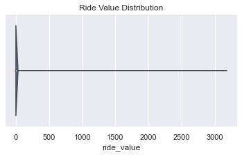

```python
# Ride Value violinplot
plt.figure(figsize=(6,3))
sns.violinplot(x=data.iloc[:, 5],pallete='viridis')
plt.title('Ride Value Distribution')
plt.xlabel('ride_value')
plt.show()
```

The violinplot show high value outliers, which will be removed. First I will explore the dependency of the ride_value variable with the ride_distance variable:

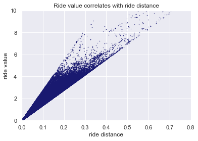

```python
#create ride_distance variable
data['ride_distance'] =np.sqrt((data['end_lat']-data['start_lat'])**2+(data['end_lng']-data['start_lng'])**2)

#plot the relationship
plt.scatter(data['ride_distance'],data['ride_value'],s=0.1,color='midnightblue')
plt.ylabel('ride value')
plt.xlabel('ride distance')
plt.title('Ride value correlates with ride distance')
plt.ylim((0,10))
plt.xlim((0,0.8))
plt.show()
```

A high correlation between the two variables. Later I want the ride value to reflect the demand, increase it when the demand increases. The surge pricing model does not depend on the distance travelled but only on the point of origin. Two riders from the same location should have the same cost basis, regardles of their destination, but dependent on the demand density in their location. For the ride value to reflect the demand, it should be normalized to distance unit.

**Normalzing the ride_value variable to ride_distance:**

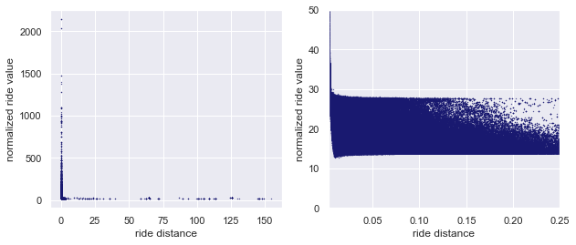

```python
#generatign the normalized value variable
data['norm_value'] = data['ride_value']/data['ride_distance']

#ploting the new reltionship between normalised ride value and distance traveled
fig,ax = plt.subplots(1,2,figsize=(10,4))
ax[0].scatter(data['ride_distance'],data['norm_value'],s=0.1,color='midnightblue')
ax[0].set_xlabel('ride distance')
ax[0].set_ylabel('normalized ride value')
ax[1].scatter(data['ride_distance'],data['norm_value'],s=0.1,color='midnightblue')
ax[1].set_xlabel('ride distance')
ax[1].set_ylabel('normalized ride value')
ax[1].set_xlim((0.0025,0.25))
ax[1].set_ylim((0,50))
plt.show()
```

The left figure is without x/y limits and it shows that very low distance rides have a very high normalized value. The right figure is a zoom in on the y axis and shows that most values are in the range of 13-30. Normalised values larger than 30 will be removed due to short distance distortions.

**Next, I will remove the extremely high values of ride value and the data points associated with them:**

```python
# Removing high normalized ride value ( = very low distance travelled):
number_of_data_points = len(data)
cleaned_data = data.loc[data['norm_value']<30,:]
print(number_of_data_points-len(cleaned_data),' data points were removed')
cleaned_data['norm_value'].describe()
```

```
7566  data points were removed
```

```
count    619644.000000
mean         17.651973
std           4.062728
min          12.813037
25%          14.372935
50%          16.044776
75%          19.750237
max          29.997920
Name: norm_value, dtype: float64
```

## 2. Remove geographic coordinate outliers

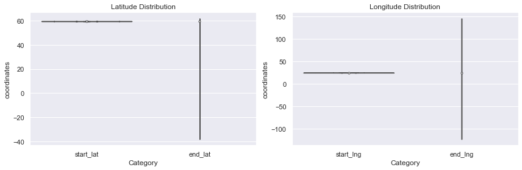

```python
fig, ax = plt.subplots(1, 2, figsize=(12, 4))

#Latitude Distribution violinplot
df_lat = pd.melt(cleaned_data.iloc[:, [1, 3]], var_name='Category', value_name='Value')
sns.violinplot(x='Category', y='Value', data=df_lat, ax=ax[0])
ax[0].set_title('Latitude Distribution')
ax[0].set_ylabel('coordinates')

# Longitude Distribution violinplot
df_lng = pd.melt(cleaned_data.iloc[:, [2, 4]], var_name='Category', value_name='Value')
sns.violinplot(x='Category', y='Value', data=df_lng, ax=ax[1])
ax[1].set_title('Longitude Distribution')
ax[1].set_ylabel('coordinates')

plt.tight_layout()
plt.show()
```

Both descriptive statistics and violin plots show the geographic coordinates contain outliers. Outliers damage forecasting models both mathematically and conceptually. I will remove them based on 1.5*IQR criteria:

```python
# columns to check for outliers
columns_to_check = ['start_lat', 'start_lng', 'end_lat', 'end_lng']

outlier_indices = set()
for col in columns_to_check:
    # Calculate Q1 (25th percentile) and Q3 (75th percentile) for the column
    Q1 = cleaned_data[col].quantile(0.25)
    Q3 = cleaned_data[col].quantile(0.75)
    IQR = Q3 - Q1

    # Determine the bounds for outliers
    lower_bound = Q1 - 1.5 * IQR
    upper_bound = Q3 + 1.5 * IQR

    # Find indices of outliers in the current column
    col_outliers = cleaned_data[(cleaned_data[col] < lower_bound) | (cleaned_data[col] > upper_bound)].index

    # Add these indices to the set of outlier indices
    outlier_indices.update(col_outliers)

# Remove all outliers
df = cleaned_data.drop(index=outlier_indices)
# the entire data post QC is now called "df"

print(f'Original data had {data.shape[0]} rows.')
print(f'After removing outliers: {df.shape[0]} rows.')
```

```
Original data had 627210 rows.
After removing outliers: 480495 rows.
```

The critiria of 1.5*UQR is arbitrary, but is considered a common practice. Here it ends up removing a substantial part of the data, though I am left with still a considerable amount, certainly for a baseline model. In a real-world problem I'd discuss with product managers to have a better understanding which data limits are suitable for this particular problem and modify the exclusion criteria accordinlgy.

```python
df.describe()
```

|  | start_lat | start_lng | end_lat | end_lng | ride_value | ride_distance | norm_value |
| --- | --- | --- | --- | --- | --- | --- | --- |
| count | 480495.000000 | 480495.000000 | 480495.000000 | 480495.000000 | 480495.000000 | 480495.000000 | 480495.000000 |
| mean | 59.428163 | 24.739863 | 59.426922 | 24.741498 | 0.933191 | 0.057100 | 17.556428 |
| std | 0.014517 | 0.042399 | 0.016218 | 0.049676 | 0.569467 | 0.038929 | 4.073860 |
| min | 59.387634 | 24.629260 | 59.378298 | 24.607254 | 0.110151 | 0.003903 | 12.813037 |
| 25% | 59.420263 | 24.715961 | 59.416509 | 24.710737 | 0.465750 | 0.026102 | 14.363996 |
| 50% | 59.431552 | 24.743907 | 59.430136 | 24.743531 | 0.845250 | 0.049027 | 15.876229 |
| 75% | 59.438070 | 24.761878 | 59.438209 | 24.767671 | 1.307750 | 0.080095 | 19.489686 |
| max | 59.469909 | 24.851715 | 59.475769 | 24.874036 | 3.575000 | 0.245539 | 29.997920 |

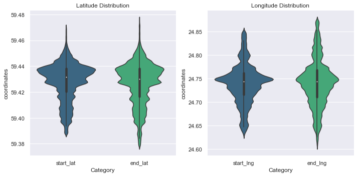

```python
fig, ax = plt.subplots(1, 2, figsize=(10, 5))

#Latitude Distribution violinplot
df_lat = pd.melt(df.iloc[:, [1, 3]], var_name='Category', value_name='Value')
sns.violinplot(x='Category', y='Value', data=df_lat, ax=ax[0],palette='viridis')
ax[0].set_title('Latitude Distribution')
ax[0].set_ylabel('coordinates')

# Longitude Distribution violinplot
df_lng = pd.melt(df.iloc[:, [2, 4]], var_name='Category', value_name='Value')
sns.violinplot(x='Category', y='Value', data=df_lng, ax=ax[1],palette='viridis')
ax[1].set_title('Longitude Distribution')
ax[1].set_ylabel('coordinates')

plt.tight_layout()
plt.show()
```

## 3.Aggregate ride demands into bins based on geographical coordinates, per time period

```python
# Generate a hexagon-grid demand density plot displayed on the Tallinn city map

def hexgridMap(ax,df,title,xmin=0,xmax=0,ymin=0,ymax=0,colorMagnitude=4.5):

    # GeoDataFrame from data coordinates
    geometry = [Point(xy) for xy in zip(df.start_lng, df.start_lat)]
    gdf = gpd.GeoDataFrame(df, geometry=geometry, crs='EPSG:4326')
    # Convert to Web Mercator projection
    gdf = gdf.to_crs(epsg=3857)
    # Extract x and y coordinates from the GeoDataFrame
    x = gdf.geometry.x
    y = gdf.geometry.y

    # Define the hexbin parameters
    gridsize = 35

    # colormap where the first color is transparent
    cmap = ListedColormap([(0,0,0,0)] + plt.cm.viridis.colors)
    norm = BoundaryNorm(boundaries=np.logspace(0, colorMagnitude, cmap.N), ncolors=cmap.N)

    # hexbin plot for number of rides
    hb = ax.hexbin(x, y, gridsize=gridsize, cmap=cmap,norm=norm, mincnt=0, linewidths=0.2)

    # Add a color bar
    cb = plt.colorbar(hb, extend='max', ax=ax)
    cb.set_label('Number of Rides')

    # Add the basemap
    ctx.add_basemap(ax, crs=gdf.crs.to_string(), source=ctx.providers.OpenStreetMap.Mapnik)

    # Set limits to match the data
    if xmin==0:
        xmin,xmax = x.min(),x.max()
        ymin,ymax = y.min(),y.max()
    ax.set_xlim(xmin,xmax)
    ax.set_ylim(ymin,ymax)

    # Set axis labels and title
    ax.set_xlabel('Ride Start Longitude')
    ax.set_ylabel('Ride Start Latitude')
    ax.set_title('Demand Map, Tallinn, '+title)


    xlim = plt.gca().get_xlim()
    ylim = plt.gca().get_ylim()
    lng_edges = np.linspace(xlim[0], xlim[1], gridsize + 1)
    lat_edges = np.linspace(ylim[0], ylim[1], gridsize + 1)
    return  xmin,xmax,ymin,ymax,lng_edges,lat_edges,x,y
```

[figure not shown]

```python
fig,ax = plt.subplots(figsize=(12, 5))
xmin,xmax,ymin,ymax,lng_edges,lat_edges,x_coord,y_coord= hexgridMap(ax,df,"Four Weeks",colorMagnitude=4.5)
plt.show()
```

This is the aggregated demand map for the entire 28-day duration, geogrpahically distributed. The number of bins was selected to optimize for 1hr-interval density grid, which under current conditions became somewhat sparse. This variable needs to be altered accroding to resolution requirements described by product managers, with the understanding that the degrees of freedom are limited by the size of the data and the forecasting interval required. (The coordinates of this map are different from the ones provided, and are provided by the GeoDataFrame.)

[figure not shown]

```python
fig,ax = plt.subplots(figsize=(12, 5))
hour = np.random.randint(0,hours)
day = np.random.randint(1,days+1)
df_filtered = df[(df['start_time'].dt.day == day)&(df['start_time'].dt.hour == hour)]
hexgridMap(ax,df_filtered,"hour = "+str(hour)+", day = "+str(day),xmin,xmax,ymin,ymax,colorMagnitude=1.25)
plt.show()
```

Demand geomap for a single hour in a single day. The data is becoming sparse at this time scale. Ideally I would like to have shorter time periods for better forecasting resolution, however sparse data can make forecasting unreliable. This 1-hour time window will be used to forecast the demand map, at one hour intervals. For modeling the geographic distribution of the damand I will use the hour hexagon values as both features and labels.

## 4. Calculate hourly geographic demand and correlation between variables

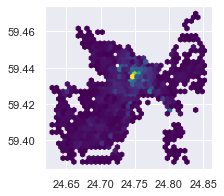

```python
# save coordinates so all hexgrids in future maps will align
plt.figure(figsize=(3,3))
cmap = ListedColormap([(0,0,0,0)] + plt.cm.viridis.colors)
gridsize=35
hb = plt.hexbin(x=df.start_lng, y=df.start_lat, gridsize=gridsize,cmap=cmap)
xlim = plt.gca().get_xlim()
ylim = plt.gca().get_ylim()
lng_edges = np.linspace(xlim[0], xlim[1], gridsize + 1)
lat_edges = np.linspace(ylim[0], ylim[1], gridsize + 1)
```

```python
# divides data into hexagon bins, per hours in the data:
# aggregates the mean of normalized ride values
# aggregates the sum of distance travelled out of hexagon
# aggregates the number of rides = nRides

def aggregateBinRides(df, hexbin_edges):
    # Define bins for latitude and longitude based on hexbin edges
    lat_bins = hexbin_edges[:, 0]
    lng_bins = hexbin_edges[:, 1]

    # Digitize the latitude and longitude values to find their respective bins
    lat_indices = np.digitize(df['start_lat'], lat_bins, right=True) - 1
    lng_indices = np.digitize(df['start_lng'], lng_bins, right=True) - 1

    # Ensure that indices within the bins range
    lat_indices = np.clip(lat_indices, 0, len(lat_bins) - 1)
    lng_indices = np.clip(lng_indices, 0, len(lng_bins) - 1)

    # Create a multi-index for the bins
    df['bin'] = list(zip(lat_indices, lng_indices))

    # Group by the bin and mean the normalized ride values, sum of distances, and count of rides
    binned_values = df.groupby('bin')['norm_value'].mean().reset_index()
    binned_distances = df.groupby('bin')['ride_distance'].sum().reset_index()
    binned_nRides = df.groupby('bin')['norm_value'].count().reset_index()

    # Create all possible bin combinations
    all_bins = pd.MultiIndex.from_product([range(len(lat_bins) - 1), range(len(lng_bins) - 1)], names=['lat_bin', 'lng_bin'])

    # Reindex the binned_df to include all possible bins
    binned_values = binned_values.set_index('bin').reindex(all_bins, fill_value=0).reset_index()
    binned_distances = binned_distances.set_index('bin').reindex(all_bins, fill_value=0).reset_index()
    binned_nRides = binned_nRides.set_index('bin').reindex(all_bins, fill_value=0).reset_index()

    return binned_values['norm_value'],binned_nRides['norm_value'],binned_distances['ride_distance']
```

```python
# takes about 30 seconds to run

hexbin_edges = np.array([lat_edges, lng_edges]).T
meanNormValuesMat = np.zeros((days * hours, gridsize*gridsize))
nRidesMat = np.zeros((days * hours, gridsize*gridsize))
sumDistancesMat = np.zeros((days * hours, gridsize*gridsize))

#loops over all hours in the data and aggregate the variables into bins
print('Started Aggregating Rides into Bins')
for i in range(0,days * hours):
    if (i%200==0):
        print(i)
    day_i = (i // hours) + 1
    hour_i = i % hours
    #filter the data of specific hour
    df_i = df[(df['start_time'].dt.day == day_i) & (df['start_time'].dt.hour == hour_i)]
    #save in respective matrices
    meanNormValuesMat[i,:],nRidesMat[i,:],sumDistancesMat[i,:] = aggregateBinRides(df_i,hexbin_edges )

#loop over all hours and calculate the correlation of the hexagons hourly data
print('Started Calculating Correlations')
corrMat_nRide_vs_values = np.zeros((days * hours,days * hours))
corrMat_nRide_vs_nRides = np.zeros((days * hours,days * hours))
corrMat_values_vs_values = np.zeros((days * hours,days * hours))
for i in range(0, days * hours):
    if (i%200==0):
        print(i)
    for j in range(0, i):  #loop over the lower triangle
        corrMat_nRide_vs_values[i, j] = np.corrcoef(nRidesMat[i,:], meanNormValuesMat[j,:])[0, 1]
        corrMat_nRide_vs_nRides[i, j] =  np.corrcoef(nRidesMat[i,:], nRidesMat[j,:])[0, 1]
        corrMat_values_vs_values[i, j] = np.corrcoef(meanNormValuesMat[i,:], meanNormValuesMat[j,:])[0, 1]
```

```
Started Aggregating Rides into Bins
0
200
400
600
Started Calculating Correlations
0
200
400
600
```

**Plotting the correlation matrices and correlation distributions**

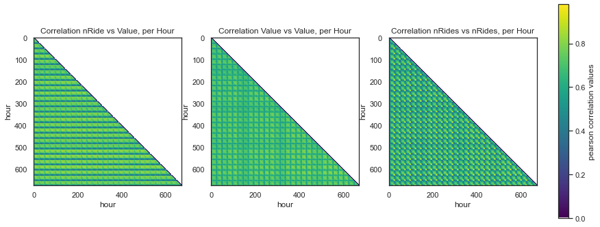

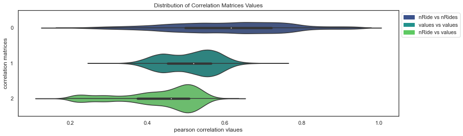

```python
# Flatten hexagon grid per-hour correlation matrices

fig,axs = plt.subplots(1,3,figsize=(14, 10))
cmap = ListedColormap([(1, 1, 1)] + plt.cm.viridis.colors)

# Plot the heatmaps
cax1 = axs[0].imshow(corrMat_nRide_vs_values, cmap=cmap)
axs[0].set_xlabel('hour')
axs[0].set_ylabel('hour')
axs[0].set_title('Correlation nRide vs Value, per Hour')

cax2 = axs[1].imshow(corrMat_values_vs_values, cmap=cmap)
axs[1].set_xlabel('hour')
axs[1].set_ylabel('hour')
axs[1].set_title('Correlation Value vs Value, per Hour')

cax3 = axs[2].imshow(corrMat_nRide_vs_nRides, cmap=cmap)
axs[2].set_xlabel('hour')
axs[2].set_ylabel('hour')
axs[2].set_title('Correlation nRides vs nRides, per Hour')

cbar = fig.colorbar(cax3, ax=axs, orientation='vertical', fraction=0.02, pad=0.04)
cbar.set_label('pearson correlation values')


# Flatten hexagon grid per-hour correlation distribution

# Data for violin plot
violin_data = [
    corrMat_nRide_vs_nRides.flatten(),
    corrMat_values_vs_values.flatten(),
    corrMat_nRide_vs_values.flatten()]

violin_data = [data[data != 0] for data in violin_data]

# Create the violin plot
plt.figure(figsize=(14, 4))
sns.set_style("white")

sns.violinplot(data=violin_data,palette='viridis', orient='h')
plt.xlabel('pearson correlation vlaues')
plt.ylabel('correlation matrices')
plt.title('Distribution of Correlation Matrices Values')

colors = sns.color_palette('viridis', n_colors=len(violin_data))
labels = ['nRide vs nRides', 'values vs values', 'nRide vs values']
handles = [patches.Patch(color=colors[i], label=labels[i]) for i in range(len(violin_data))]

plt.legend(handles=handles, loc='upper left', bbox_to_anchor=(1, 1))
plt.show()
```

Correlation matrix shows repeating patterns with variations. The patterns repeat every 24hrs which is expected.

Overall correlation for hourly demand patterns (nRides vs nRides) is positive, which is not surprising as areas with high demand (city centers, airport) generally stay in high demand, relative to other areas, regardless of the hour of day. There is a broad correlation-values distriburion with some hours showing high degree of correlations between them (>0.8). A predictive model could make use of the strong temporo-spacial correlations in order to forecast the geographically distributed demand pattern.

The correlation between the demand and the normalized (per distance unit) ride value is weakly correlated, with a median of ~0.5, suggesting that a dynamic cost model doesn't exist for the current data. I will explore this result later.

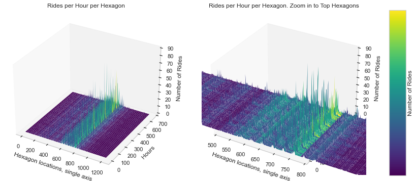

```python
from mpl_toolkits.mplot3d import Axes3D

# Apply a Seaborn style
sns.set(style="whitegrid")

# Reshape the matrix to match the specified dimensions
data = nRidesMat.reshape(days * hours, gridsize * gridsize)

# Create the X and Y coordinates
x = np.arange(gridsize * gridsize).reshape(gridsize, gridsize)
y = np.arange(days * hours).reshape(days * hours)

# Create meshgrid for 3D plotting
X, Y = np.meshgrid(x, y)

fig = plt.figure(figsize=(16, 10))

# First subplot
ax1 = fig.add_subplot(121, projection='3d')

# Plot the surface with a colormap of your choice
surface1 = ax1.plot_surface(X, Y, data, cmap='viridis', edgecolor='none')

# Add labels and title
ax1.set_xlabel('Hexagon locations, single axis')
ax1.set_ylabel('Hours')
ax1.set_zlabel('Number of Rides')
ax1.set_title('Rides per Hour per Hexagon')
ax1.grid(False)

# Second subplot
ax2 = fig.add_subplot(122, projection='3d')

# Plot the surface
surface2 = ax2.plot_surface(X, Y, data, cmap='viridis', edgecolor='none')

ax2.set_xlabel('Hexagon locations, single axis')
ax2.set_xlim((500, 800))
ax2.set_ylabel('Hours')
ax2.set_zlabel('Number of Rides')
ax2.set_title('Rides per Hour per Hexagon. Zoom in to Top Hexagons')

ax2.grid(False)
cbar = fig.colorbar(surface1, ax=[ax1, ax2], shrink=0.6, aspect=10)
cbar.set_label('Number of Rides')
cbar.set_ticks([])
plt.show()
```

The Y axis are the hours. The X axis is the hexagon density plot with the 35x35 hexgrid flattened to a vector. Most of the hexes are low demand areas, which stay in low demand throughout the entire data period. A model that aligns supply and demand more effeciently will do better if it were to limit its predictions only to the high demand hexagons (and avoid the errors that a larger, sparser training set may generate).

## 5. No correlation between normalized ride values and demand

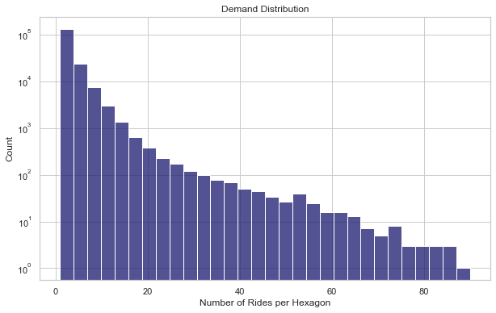

```python
#plotting the demand counts: the number of hexagons with each number of rides hailed
fig, ax = plt.subplots(figsize=(10, 6))
hist = sns.histplot(nRidesMat[nRidesMat>0].flatten(),bins=30,color='midnightblue')
ax.set_xlabel('Number of Rides per Hexagon')
ax.set_yscale('log')
ax.set_title('Demand Distribution')
```

```python
#calculating the mean of means of normalized values for each hexagon, groupedby the number of rides
# as well as the std

nMax = int(nRidesMat.max())
meanMeanValue = np.zeros(nMax)
stdMeanValue = np.zeros(nMax)
for i in range(nMax):
    meanMeanValue[i] = meanNormValuesMat.flatten()[(nRidesMat.flatten()==i)].mean()
    stdMeanValue[i] = meanNormValuesMat.flatten()[(nRidesMat.flatten()==i)].std()

not_nan_idx = ~np.isnan(meanMeanValue)
meanMeanValue = meanMeanValue[not_nan_idx][1:]
stdMeanValue = stdMeanValue[not_nan_idx][1:]
nRides_x = np.arange(nMax).reshape(-1,1)[not_nan_idx][1:]

#fit a linear regression model to the data
linearModel = LinearRegression()
linearModel.fit(nRides_x,meanMeanValue.reshape(-1,1))
mse = mean_squared_error(nRides_x,linearModel.predict(nRides_x))
r_squared = r2_score(nRides_x,linearModel.predict(nRides_x))
```

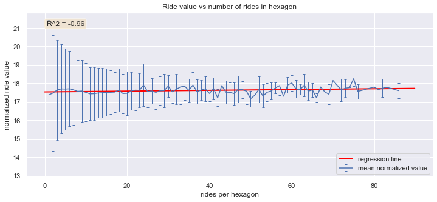

```python
# plot the results
trueCoef = linearModel.coef_[0, 0]
trueIntercept = linearModel.intercept_[0]

plt.figure(figsize=(12,5))
props = dict(boxstyle='round', facecolor='wheat', alpha=0.5)
plt.gca().text(0.05, 0.95, f'R^2 = {r_squared:.2f}', transform=plt.gca().transAxes, fontsize=12,
                verticalalignment='top', bbox=props)
plt.errorbar(nRides_x,meanMeanValue,yerr=stdMeanValue,elinewidth=1,capsize=2,label ='mean normalized value')
plt.plot(np.arange(0,nMax,nMax/500),linearModel.predict(np.arange(0,nMax,nMax/500).reshape(-1,1)),color="red",linewidth=2,label='regression line')
plt.legend(loc='lower right')
plt.xlabel('rides per hexagon')
plt.ylabel('normalized ride value')
plt.title('Ride value vs number of rides in hexagon')
plt.show()
```

The mean of values of hexagons with identical number of rides does not increase with increasing number of rides. In fact, the mean ride value is constant across different demand areas. this culminates in inefficiencies as drivers don't have incentives to localize in high demand areas, probably causing long waiting times for riders in high demand areas.

## 6. Suggested surge cost model

Two models are suggested, linear increase and exponential increase. The specific parameters used to construct the model will have to be set after research into the cost flexibility of rides, using historical data and discussions with product managers and stakeholders. The model should reach an equlibrium between incetivizing drivers, and not reducing the demand too much, due to increased prices, or at least reduce the demand in an amount that is offset by an increase in revenue from increased costs for high demand areas. The success of the cost model and its effect on demand, time queues and revenues will be monitored in the testing phase (see part 9).

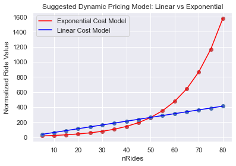

```python
#parameters of the surge cost model
a_lnr=5
b_x0=13
a_exp=0.06

nRides = np.arange(5,85,5)
linearCost = b_x0+ nRides*a_lnr
expCost = b_x0 * np.exp(a_exp* nRides)

# Plotting the suggested surge cost curves
plt.plot(nRides, expCost,"ro")
plt.plot(nRides, b_x0 * np.exp(a_exp * nRides), color="red", label="Exponential Cost Model")
plt.plot(nRides,linearCost,"bo")
plt.plot(nRides,a_lnr * nRides + b_x0,color="blue", label="Linear Cost Model")
plt.xlabel("nRides")
plt.ylabel("Normalized Ride Value")
plt.title('Suggested Dynamic Pricing Model: Linear vs Exponential')
plt.legend()
plt.show()
```

This equations will be be used to direct drivers into expected high demand regions in the second part of the A/B testing period, based on the demand prediction models presented below

## 7. Generate models to predict demand for the next time period, based on geographical coordinates

Goal: Predict the geographic demand distribution in the next hour, based on histroical data

#### Long-Short Term Memory LSTM:

Advantages: can capture long-term dependencies and patterns in sequential data, making them suitable for time series with complex, non-linear trends and seasonality. Flexible for accurate prediction of multiple steps ahead.

Disadvatnages: Training LSTMs can be time-consuming and computationally expensive, and requires more sophisticated infrastructure. Maintainance requires careful monitoring of performance.

#### EMA - Exponential Moving Average:

Advantages: Can be very effective for short-term predictions and simple patterns, supplying extremly fast results and doesn't require a lot of overhead and maintnance.

Disadvatnages: May not capture complex patterns in the data

**Other possible models (not tested in this anlysis):**

ARIMA: Combines autoregression, differencing, and moving averages to capture linear relationships in time series data. It is effective for univariate time series with strong temporal dependencies.

Prophet: Designed to handle time series with daily observations that display seasonality and holiday effects.

### LSTM

Data features: the geographically distributed demand in hexagons, per 1-hour time point.

Testset: 20% of the data, the final 130 hours in the data.

Adam optimizer with learning rate of 0.001 and weight decay of 0.0001.

Node dropout rate of 0.4 in training.

Number of epochs was kept at 20.

Naturally these parameters will have to be tested and compared, but the goal here is to present a baseline model and general solution scheme.

**Hyperparamteres tested:**

number of nodes in the hidden layers.

number of time steps used for forecasting, longer time steps require more computation but may capture more complex dependencies .

number of hexagons used to train: high demand hexagons constitute a fraction of the total 1225 hexagons (see above), training the data on the most high demand areas will save time in training the model and would probably be more accurate for those specific hexagons, as sparse data is removed.

```python
class LSTMModel(nn.Module):
    def __init__(self, input_size, hidden_size, output_size, num_layers=2, dropout=0.4):
        super(LSTMModel, self).__init__()
        self.lstm = nn.LSTM(input_size, hidden_size, num_layers=num_layers,
                            batch_first=True, dropout=dropout)
        self.fc = nn.Linear(hidden_size, output_size)

    def forward(self, x):
        h0 = torch.zeros(self.lstm.num_layers, x.size(0), self.lstm.hidden_size).to(x.device)
        c0 = torch.zeros(self.lstm.num_layers, x.size(0), self.lstm.hidden_size).to(x.device)
        out, _ = self.lstm(x, (h0, c0))
        out = self.fc(out[:, -1, :])
        return out

def create_lstm_dataset(data, time_steps):
    X, y = [], []
    for i in range(len(data) - time_steps):
        X.append(data[i:i + time_steps])
        y.append(data[i + time_steps])
    return np.array(X), np.array(y)

def LSTM_training(nRides_hexes_days_hours,hidden_size,time_steps,nTopHexagons):

    # limit the data for high demand hexagons
    hexagons_sums = np.sum(nRides_hexes_days_hours, axis=0)
    top_hexagons = np.argsort(hexagons_sums)[::-1][:nTopHexagons]
    data_top_hexagons = nRides_hexes_days_hours[:, top_hexagons]

    # Normalize data
    LSTM_scaler = MinMaxScaler()
    data_top_hexagons = LSTM_scaler.fit_transform(data_top_hexagons)

    # Prepare the dataset for LSTM
    X, y = create_lstm_dataset(data_top_hexagons, time_steps)
    X = torch.tensor(X, dtype=torch.float32)
    y = torch.tensor(y, dtype=torch.float32)

    # Split into train and test sets
    split = int(len(X) * 0.8)
    X_train, X_test = X[:split], X[split:]
    y_train, y_test = y[:split], y[split:]

    # Create DataLoader instances for training and testing
    train_dataset = TensorDataset(X_train, y_train)
    test_dataset = TensorDataset(X_test, y_test)
    train_loader = DataLoader(train_dataset, batch_size=32, shuffle=True,drop_last=True)
    test_loader = DataLoader(test_dataset, batch_size=32, shuffle=False)

    # Initialize the model
    input_size = X_train.shape[2]
    output_size = y_train.shape[1]
    model = LSTMModel(input_size, hidden_size, output_size)

    # Loss function and optimizer
    criterion = nn.MSELoss()
    optimizer = optim.Adam(model.parameters(), lr=0.001, weight_decay=0.0001)

    # Train the model
    num_epochs = 20
    for epoch in range(num_epochs):
        model.train()
        for X_batch, y_batch in train_loader:
            outputs = model(X_batch)
            loss = criterion(outputs, y_batch)
            optimizer.zero_grad()
            loss.backward()
            optimizer.step()

        # Validation
        model.eval()
        with torch.no_grad():
            test_loss = 0
            for X_batch, y_batch in test_loader:
                outputs = model(X_batch)
                test_loss += criterion(outputs, y_batch).item()

    # Evaluation
    model.eval()
    with torch.no_grad():
        y_pred = []
        y_true = []
        for X_batch, y_batch in test_loader:
            outputs = model(X_batch)
            y_pred.append(outputs.numpy())
            y_true.append(y_batch.numpy())

        y_pred = np.concatenate(y_pred, axis=0)
        y_true = np.concatenate(y_true, axis=0)

    #MSE for each feature
    mse_values = np.zeros(output_size)
    for feature in range(output_size):
        mse_values[feature] = mean_squared_error(y_true[:, feature], y_pred[:, feature])

    #sum for each feature
    mse = np.sum(mse_values)

    return mse,LSTM_scaler,y_pred,y_true,mse_values
```

```python
# trianing the model through the grid of hyperparameters takes about 20 minutes
hiddenSizes = np.array([50,100,200])
timeStepsArr = np.array([3,12,24,48,96])
nTopHexagonsArr = np.array([400,300,200,100,50])
LSTMmseMatrix = np.zeros((len(hiddenSizes),len(timeStepsArr),len(nTopHexagonsArr)))
for i,hiddenSize in enumerate(hiddenSizes):
    print('Calculating for hidden size =',hiddenSize)
    for j,timeSteps in enumerate(timeStepsArr):
        for k,nTopHexagons in enumerate(nTopHexagonsArr):
            LSTMmseMatrix[i,j,k],_,_,_,_= LSTM_training(nRidesMat,hiddenSize,timeSteps,nTopHexagons)
```

```
Calculating for hidden size = 50
Calculating for hidden size = 100
Calculating for hidden size = 200
```

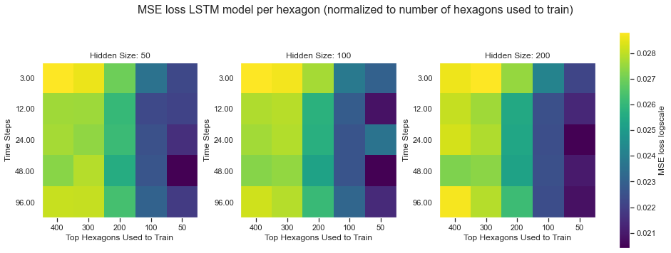

```python
#Display the MSE results for the hyperparameters tested

fig, ax = plt.subplots(1, 3, figsize=(14, 5))

for i in range(3):
    im = ax[i].matshow(LSTMmseMatrix[i,:,:]/nTopHexagonsArr, cmap='viridis')

    ax[i].grid(False)
    ax[i].set_title(f'Hidden Size: {hiddenSizes[i]}')
    ax[i].set_xlabel('Top Hexagons Used to Train')
    ax[i].set_ylabel('Time Steps')
    ax[i].set_xticks(np.arange(len(nTopHexagonsArr)))
    ax[i].set_xticklabels(nTopHexagonsArr)
    ax[i].xaxis.set_ticks_position('bottom')
    ax[i].set_yticks(np.arange(len(timeStepsArr)))
    ax[i].set_yticklabels([f'{y:.2f}' for y in timeStepsArr])

plt.tight_layout(rect=[0, 0, 0.9, 0.95])
cbar = fig.colorbar(im, ax=ax.ravel().tolist(), orientation='vertical', fraction=0.025, pad=0.04)
cbar.set_label('MSE loss logscale')
fig.suptitle('MSE loss LSTM model per hexagon (normalized to number of hexagons used to train)', fontsize=16, y=1.02)
plt.show()
```

The MSE loss results are shown normalized per hexagon. As expected the less hexagons used to train the model the better the accuracy of prediction, per hexagon. This number should be considered not only from the perspective of overall MSE results, but also from practical usability - the model should display as many hexagons as possible so drivers know the prices of as many locations as possible. The equillibrium between these opposing considerations should be discussed with product managers.

Regarding time steps, 24hr-48hrs seem optimal, depending on the size of the hidden layer.

**Below is an example result for a set of hyperparameters:**

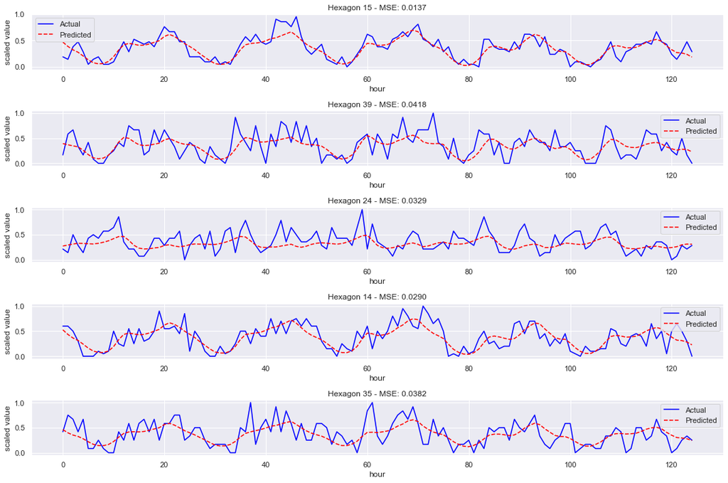

```python
#Show example for results of hidden_size=50 , time_steps=48 ,nTopHexagons=400
LSTM_mse,LSTM_scaler,LSTM_test_pred,LSTM_test_data,LSTM_mse_values= LSTM_training(nRidesMat,hidden_size=50,time_steps=48,nTopHexagons=400)

#accumulated sum for each feature in the test set
hexagons_sums_test = np.sum(np.abs(LSTM_test_data), axis=0)
top_hexagons_test = np.argsort(hexagons_sums_test)[-5:]  # Indices of top 5 features

# Plotting results for the top 5 hexagons
plt.figure(figsize=(15, 10))
for i, hexagon in enumerate(top_hexagons_test):
    plt.subplot(5, 1, i + 1)
    plt.plot(LSTM_test_data[:, hexagon], label='Actual', color='blue')
    plt.plot(LSTM_test_pred[:, hexagon], label='Predicted', color='red', linestyle='--')
    plt.title(f'Hexagon {hexagon} - MSE: {LSTM_mse_values[hexagon]:.4f}')
    plt.xlabel('hour')
    plt.ylabel('scaled value')
    plt.legend()
plt.tight_layout()
plt.show()
```

Showing The prediction vs true demand values for a specific set of hyperparameters for the final 130hrs of the top 5 locations in highest demand.

The model succesffuly predicts the general pattern of the demand, but doesn't adapt fast enough to spikes in demand.

### EMA

Data features: the geographically distributed demand in hexagon, per 1-hour time point. Testset: 20% of the data, the final 130 hours in the data.

**hyperparamteres tested:**

The alpha parameter: determines how much of the previous timepoint value is carried over to the current time point prediction.

Number of hexagons used to train: same as with LSTM model, high demand hexagons constitute a fraction of the total 1225 hexagons (see above), training the data on the most high demand areas will probably be more accurate for those specific hexagons, as sparse data is removed.

```python
# Define the Exponential Moving Average function
def exponential_moving_average(data, alpha):
    ema = np.zeros_like(data)
    ema[0] = data[0]
    for t in range(1, len(data)):
        ema[t] = alpha * data[t] + (1 - alpha) * ema[t - 1]
    return ema

def EMA_training(nRidesMat,nTopHexagons,alpha):

    # Compute cumulative sums of features and select top features
    hexagons_sums = np.sum(nRidesMat, axis=0)
    top_hexagons = np.argsort(hexagons_sums)[::-1][:nTopHexagons]  # Indices of topfeatures

    # Filter data to keep only top features
    data_top_hexagons = nRidesMat[:, top_hexagons]

    # Normalize data
    EMA_scaler = MinMaxScaler()
    data_top_features = EMA_scaler.fit_transform(data_top_hexagons)

    # Split data into training and test sets
    split_index = int(0.8 * data_top_hexagons.shape[0])
    train_data = data_top_features[:split_index]
    test_data = data_top_features[split_index:]

    # Compute the EMA for each hexagon (column-wise) using the training data
    ema_matrix_train = np.apply_along_axis(exponential_moving_average, 0, train_data, alpha)

    # Forecast on the test set
    test_pred = np.zeros_like(test_data)
    for hexagon in range(test_data.shape[1]):
        test_pred[:, hexagon] = exponential_moving_average(np.concatenate([train_data[:, hexagon], test_data[:, hexagon]]), alpha)[-test_data.shape[0]:]

    add_column = np.zeros((1,test_pred.shape[1]))  # Create a column of zeros with the same number of rows as mseMatrix
    test_pred = np.vstack((add_column, test_pred[:-1, :]))  # Add the first column and remove the last column

    # Compute MSE for the test set
    mse_values = np.zeros(test_data.shape[1])
    for hexagon in range(test_data.shape[1]):
        mse_values[hexagon] = mean_squared_error(test_data[:, hexagon], test_pred[:, hexagon])

    # Print average MSE for the test set
    mse = np.sum(mse_values)
    #print(f'Average MSE for the test set: {average_mse:.4f}')

    return mse,EMA_scaler,test_pred,test_data,mse_values
```

```python
# trianing the model through the grid of hyperparameters takes about 10 seconds

alphas = np.arange(0.1,1,0.1) # Smoothing factor, between 0 and 1
nTopHexagons_array = np.array([400,300,200,100,50])
EMAmseMatrix = np.zeros((len(alphas),len(nTopHexagons_array)))
for i,alpha in enumerate(alphas):
    #print(f'Calculating for alpha = {alpha:.1f}')
    for j,nTopHexagons in enumerate(nTopHexagons_array):
        EMAmseMatrix[i,j],_,_,_,_= EMA_training(nRidesMat,nTopHexagons,alpha)
```

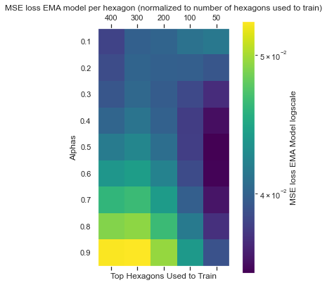

```python
#Disply the MSE results for the hyperparametrs screened

plt.matshow(EMAmseMatrix/nTopHexagons_array,norm=LogNorm(),cmap='viridis')
plt.grid(False)
plt.xlabel('Top Hexagons Used to Train')
plt.ylabel('Alphas')
plt.xticks(np.arange(len(nTopHexagons_array)), nTopHexagons_array)
plt.yticks(np.arange(len(alphas)), [round(alpha,2) for alpha in alphas])
plt.title('MSE loss EMA model per hexagon (normalized to number of hexagons used to train)')
cbar = plt.colorbar(fraction=0.08, pad=0.08)
cbar.set_label('MSE loss EMA Model logscale')
plt.show()
```

Once again, the MSE result shown are normalised per hexagon. This is an interesting result: When training for fewer hexagons the model relies more heavily on recent values, indicated by an lapha of 0.5. However when 400 hexagons are used for training the model achieved a better accuracy while relying on older values,indicated by alpha of 0.1.

**Below as an example result for a set of hyperparameters:**

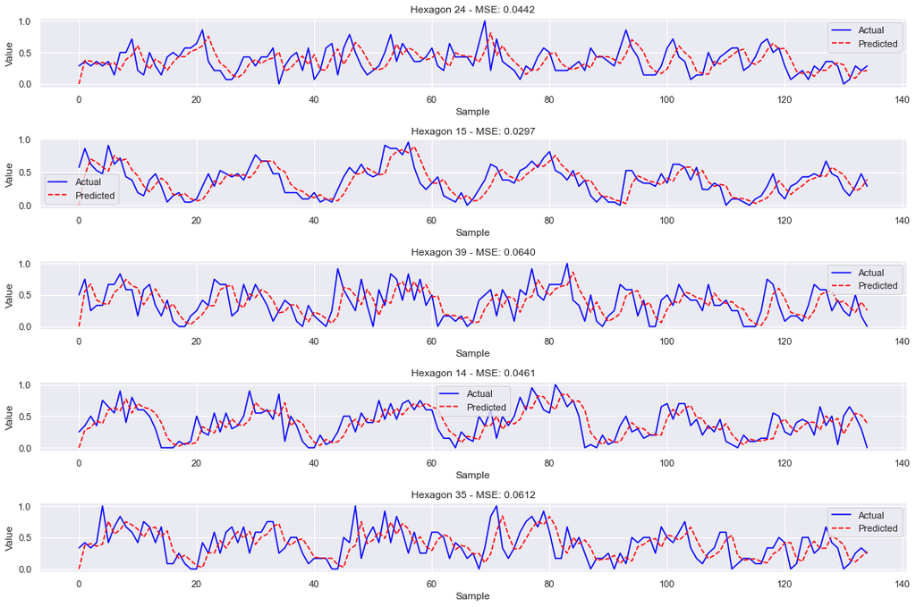

```python
#Show example for results of alpha = 0.6 nTopHexagons=400
EMA_mse,EMA_scaler,EMA_test_pred,EMA_test_data,EMA_mse_values= EMA_training(nRidesMat,nTopHexagons=400,alpha=0.6)

# Calculate the accumulated sum for each feature in the test set
hexagons_sums_test = np.sum(np.abs(EMA_test_data), axis=0)
top_hexagons_test = np.argsort(hexagons_sums_test)[-5:]  # Indices of top 5 features

# Plot the results for the top 5 hexagons
plt.figure(figsize=(15, 10))
for i, hexagon in enumerate(top_hexagons_test):
    plt.subplot(5, 1, i + 1)
    plt.plot(EMA_test_data[:, hexagon], label='Actual', color='blue')
    plt.plot(EMA_test_pred[:, hexagon], label='Predicted', color='red', linestyle='--')
    plt.title(f'Hexagon {hexagon} - MSE: {EMA_mse_values[hexagon]:.4f}')
    plt.xlabel('Sample')
    plt.ylabel('Value')
    plt.legend()
plt.tight_layout()
plt.show()
```

Showing the prediction vs true demand for a specific set of hyperparameters for the final 130hrs of the top 5 locations in top demand. Compared to the LSTM model, the EMA model's predictions are much less smoothed, capturing spikes in demand to a better extent.

```python
print(f'The mean per-hexagon MSE loss for the LSTM model is  {np.mean(LSTMmseMatrix/nTopHexagons_array):.4f}')
print(f'The mean per-hexagon MSE loss for the EMA model is  {np.mean(EMAmseMatrix/nTopHexagons_array):.4f}')
```

```
The mean per-hexagon MSE loss for the LSTM model is  0.0256
The mean per-hexagon MSE loss for the EMA model is  0.0414
```